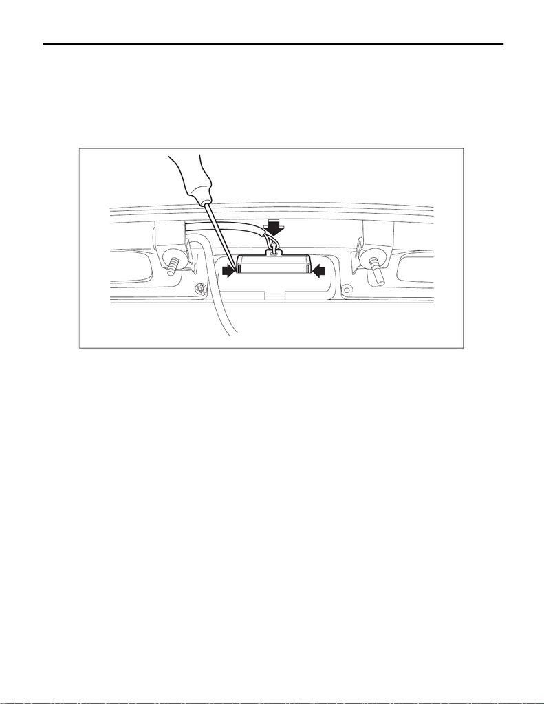

SL-97

Trunk Opener Button

SECURITY AND LOCKS

31.Trunk Opener Button

A: REMOVAL

1) Disconnect the ground cable from battery. <Ref. to NT-5, BATTERY, NOTE, Note.>

NOTE:

For models other than STI model, disconnect the ground terminal from battery sensor.

2) Remove the garnish - trunk. <Ref. to EI-51, REMOVAL, Trunk Lid Garnish.>

3) Release the locks at both ends of the trunk opener button by pushing them with a flat tip screwdriver.

B: INSTALLATION

1) Install the trunk opener button to the garnish - trunk.

2) Install the garnish - trunk.

3) Connect the battery ground terminal. <Ref. to NT-5, BATTERY, NOTE, Note.>

NOTE:

For models other than STI model, connect the ground terminal to battery sensor.

C: INSPECTION

1) Display the current data using the Subaru Select Monitor.

2) Check that the display changes when the trunk opener button is operated.

LESS ACCESS SYSTEM, INSPECTION, General Diagnostic Table.>

SL-01621